# EP08-Estadistica

Equipo 1

13-07-2026

# Contexto

Como habíamos visto a comienzos del semestre, la Encuesta de Caracterización Socioeconómica Nacional (Casen) es realizada por el Ministerio de Desarrollo Social de forma periódica para conocer la situación de los hogares chilenos con relación a aspectos demográficos, de educación, salud, vivienda, trabajo e ingresos. Es la principal fuente de información para estimar la magnitud de la pobreza y la distribución del ingreso en el país.

Se tiene a disposición un archivo CSV con un subconjunto de los datos obtenidos en la Casen 2017. El equipo debe revisar las columnas disponibles en este archivo según la descripción en el libro de códigos de la encuesta, que también queda disponible para este ejercicio. Es importante notar que en esta encuesta hay datos de carácter colectivo sobre “el hogar” del entrevistado, pero también hay datos de carácter individual, que se refieren “al jefe o la jefa de hogar” (no al entrevistado).

## Lectura de datos

```r
datos_casen <- read.csv("EP08 Datos CASEN 2017.csv")

head(datos_casen)
```

|  | id.vivienda | region | sexo | edad | ecivil | pareja | h10a | h10b | h10c | h10d | h10e | h10f | e6a | e7.subarea | e7.cod.area | e8 | o1 | oficio1 | o10 | o12 | o15 | o16 | o17 | o18 | o19 | o20 | rama1 | o23 | o24a | … |
| --- | --- | --- | --- | --- | --- | --- | --- | --- | --- | --- | --- | --- | --- | --- | --- | --- | --- | --- | --- | --- | --- | --- | --- | --- | --- | --- | --- | --- | --- | --- |
| 1 | 1101100202 | Región de Tarapacá | Mujer | 56 | Soltero(a) | No tiene pareja en el hogar | No, sin dificultad | No, sin dificultad | No, sin dificultad | No, sin dificultad | No, sin dificultad | No, sin dificultad | Educación Media Científico-Humanista | NA | NA | NA | Sí | Trabajadores no calificado | 8 | Permanente? | Trabajador por cuenta propia | NA | NA | NA | NA | NA | Comercio al por mayor y al por menor | Sólo 1 personas (el entrevistado) | No | … |
| 2 | 1101100203 | Región de Tarapacá | Mujer | 21 | Soltero(a) | No tiene pareja en el hogar | No, sin dificultad | No, sin dificultad | No, sin dificultad | No, sin dificultad | No, sin dificultad | No, sin dificultad | Educación Básica | NA | NA | NA | Sí | Trabajadores no calificado | 59 | Permanente? | Servicio doméstico puertas afuera | Plazo fijo | No tiene | Jornada completa? | Sólo diurno | Directamente con la empresa o negocio donde trabaja | Hogares privados con servicio doméstico | Sólo 1 personas (el entrevistado) | No | … |
| 3 | 1101100204 | Región de Tarapacá | Hombre | 24 | Conviviente o pareja sin acuerdo de unión civil | De hecho | No, sin dificultad | No, sin dificultad | No, sin dificultad | No, sin dificultad | No, sin dificultad | No, sin dificultad | Educación Media Científico-Humanista | NA | NA | NA | Sí | Trabajadores de los servicios y vendedores de comerci | 8 | Permanente? | Empleado u obrero del sector privado | Plazo fijo | Sí, pero no ha firmado | Jornada completa? | Sólo diurno | Directamente con la empresa o negocio donde trabaja | Hoteles y restaurantes | De 6 a 9 personas | No | … |
| 4 | 1101100205 | Región de Tarapacá | Hombre | 26 | Casado(a) | Legal | No, sin dificultad | No, sin dificultad | No, sin dificultad | No, sin dificultad | No, sin dificultad | No, sin dificultad | Técnico Nivel Superior Completo (Carreras 1 a 3 años) | Ingeniería y Profesiones Afines | Ingeniería, Industria y Construcción | Instituto Profesional | No | Trabajadores no calificado | 8 | Permanente? | Empleado u obrero del sector privado | Plazo indefinido | Sí, firmó | Jornada completa? | Rotativo o turnos | Directamente con la empresa o negocio donde trabaja | Hogares privados con servicio doméstico | De 6 a 9 personas | No | … |
| 5 | 1101100206 | Región de Tarapacá | Mujer | 62 | Soltero(a) | No tiene pareja en el hogar | No, sin dificultad | No, sin dificultad | No, sin dificultad | No, sin dificultad | No, sin dificultad | No, sin dificultad | Humanidades (Sistema Antiguo) | NA | NA | NA | Sí | Trabajadores no calificado | 8 | Permanente? | Trabajador por cuenta propia | NA | NA | NA | NA | NA | Hoteles y restaurantes | De 2 a 5 personas | No | … |
| 6 | 1101100209 | Región de Tarapacá | Mujer | 59 | Separado(a) | No tiene pareja en el hogar | No, sin dificultad | No, sin dificultad | No, sin dificultad | No, sin dificultad | No, sin dificultad | No, sin dificultad | Educación Media Científico-Humanista | NA | NA | NA | Sí | Operadores de instalaciones y máquinas y montadore | 70 | Permanente? | Empleado u obrero del sector privado | Plazo indefinido | Sí, firmó | Jornada completa? | Sólo diurno | Directamente con la empresa o negocio donde trabaja | Comercio al por mayor y al por menor | No sabe | Si | … |

# Pregunta 1

Propongan una pregunta de investigación original, que involucre la comparación de la frecuencia en que se observa un evento o característica en dos grupos independientes. Fijando una semilla propia, seleccionen una muestra aleatoria de hogares (100 < n < 150) y respondan la pregunta propuesta utilizando una prueba de permutaciones Monte Carlo. Deben reportar un intervalo de confianza para el estadístico utilizado usando las mismas remuestras.

## Pregunta de investigación

Nos centramos en el estado civil del jefe o la jefa de hogar (ecivil) y en la cantidad de hijos que declara (s4). A partir de esta última variable definimos el evento “tiene al menos un hijo” (s4 > 0). La pregunta de investigación es:

¿Es igual la proporción de jefes de hogar que tienen al menos un hijo entre quienes están casados(as) y quienes no lo están?

El estadístico de interés es la diferencia de proporciones del evento “tiene al menos un hijo” entre ambos grupos independientes (casados vs. no casados).

## Datos

```r
#Crear las remuestras
set.seed(234)

#    - Grupo: casado(a) vs. no casado(a) (a partir de ecivil)
#    - Evento: tiene al menos un hijo (a partir de s4)
datos_p1 <- datos_casen |>
  filter(!is.na(s4), !is.na(ecivil)) |>
  mutate(
    Estado_civil = factor(if_else(ecivil == "Casado(a)", "Casado", "No casado")),
    Tiene_hijos  = factor(if_else(s4 > 0, "Sí", "No"), levels = c("Sí", "No"))) |>
  select(Estado_civil, Tiene_hijos)

# Seleccionar una muestra aleatoria de hogares con 100 < n < 150
n <- 120
muestra_p1 <- datos_p1 |> slice_sample(n = n)

# Tabla de Contingencia
tabla_p1 <- table(muestra_p1$Estado_civil, muestra_p1$Tiene_hijos)
cat("Tabla de contingencia de la muestra\n")
```

```
## Tabla de contingencia de la muestra
```

```r
print(addmargins(tabla_p1))
```

```
##
##              Sí  No Sum
##   Casado     40   4  44
##   No casado  57  19  76
##   Sum        97  23 120
```

Necesitamos usar métodos con remuestreo, debido al bajo número de observaciones. Realizaremos una prueba de permutaciones Monte Carlo.

## Formulación de hipótesis

Sean $p_C$ y $p_N$ las proporciones de jefes(as) de hogar con al menos un hijo entre los grupos casado y no casado, respectivamente. Entonces:

- $H_0$: la proporción de hogares con al menos un hijo es la misma en ambos grupos: $p_C - p_N = 0$.
- $H_A$: la proporción de hogares con al menos un hijo difiere entre ambos grupos: $p_C - p_N \neq 0$.

## Estadístico de interés

El estadístico de interés es la diferencia de las proporciones del evento “tiene al menos un hijo” entre el grupo casado y el grupo no casado:

$\hat{p}_C - \hat{p}_N$.

## Remuestreo

Usamos una prueba de permutación Monte Carlo. Permutamos la columna del grupo y, en cada permutación, recalculamos la diferencia de proporciones. Efectuando el método de Monte Carlo.

```r
R <- 1999
alfa <- 0.05
set.seed(234)

# Generamos las permutaciones de la etiqueta de grupo (Estado_civil)
# incluimos la muestra original (apparent = TRUE)
remuestras <- permutations(muestra_p1, permute = Estado_civil,
                           times = R, apparent = TRUE)

dif_proporciones <- function(remuestra, ...) {
  analysis(remuestra) |>
    group_by(Estado_civil) |>
    summarise(n = n(), p = mean(Tiene_hijos == "Sí"), .groups = "drop") |>
    summarise(
      term = "Dif. proporciones",
      estimate = p[1] - p[2],
      std.error = sqrt(sum(p * (1 - p) / n))
    )
}

# Obtener la distribución de permutaciones
dist_perm <- remuestras |>
  mutate(stats = map(splits, dif_proporciones))

# Simplificar a una tabla
dist_perm_tbl <- dist_perm |>
  select(-splits) |>
  unnest(cols = stats)
```

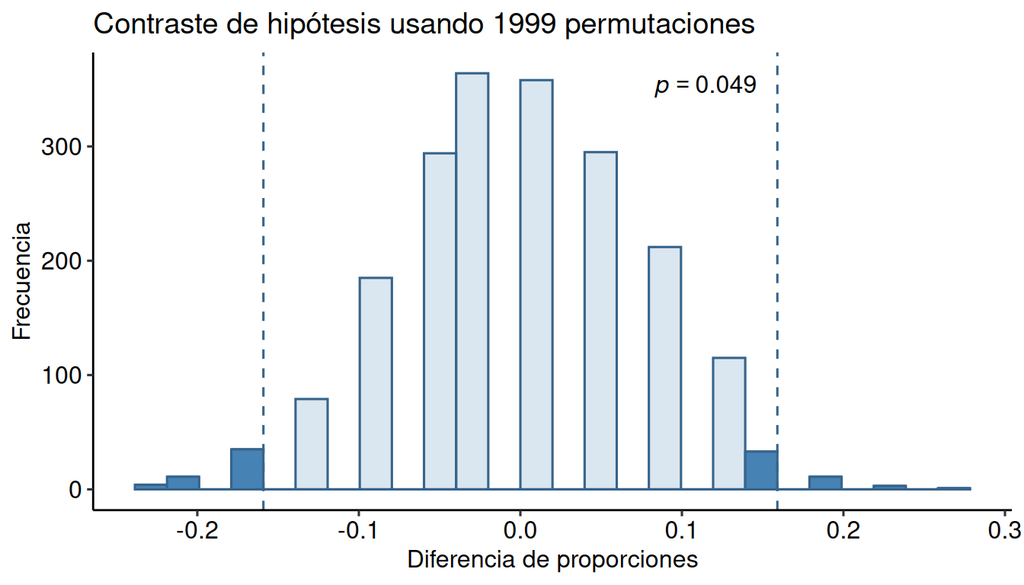

```r
# Obtener la diferencia observada en la muestra original
dif_obs <- dist_perm_tbl |>
  filter(id == "Apparent") |>
  pull(estimate)

# Calcular el valor p
n_extremos <- dist_perm_tbl |>
  filter(abs(estimate) >= abs(dif_obs)) |>
  summarise(n = n())

p_valor <- (n_extremos / (R + 1)) |> pull(n)

titulo <- paste("Contraste de hipótesis usando", R, "permutaciones")

# Construcción de etiqueta (Script 12.11 del texto base)
nota <- if_else(p_valor < 0.001,
                glue("italic(p)", " < ", "'{sprintf('%.3f', 0.001)}'"),
                glue("italic(p)", " == ", "'{sprintf('%.3f', p_valor)}'"))

ancho_barra <- diff(range(dist_perm_tbl[["estimate"]])) /
  nclass.scott(dist_perm_tbl[["estimate"]])
ancho_barra_ajustado <- abs(dif_obs) / max(1, round(abs(dif_obs) / ancho_barra))

dist_perm_pl <- dist_perm_tbl |>
  mutate(extremo = factor(if_else(abs(estimate) >= abs(dif_obs), 1, 0))) |>
  ggplot(aes(x = estimate)) +
  geom_histogram(aes(alpha = extremo), boundary = 0, binwidth = ancho_barra_ajustado,
                 color = "steelblue4", fill = "steelblue") +
  labs(title = titulo, x = "Diferencia de proporciones", y = "Frecuencia") +
  geom_vline(xintercept = c(-dif_obs, dif_obs), colour = "steelblue4",
             linetype = "dashed") +
  annotate("text", x = dif_obs, y = Inf, hjust = 1.2, vjust = 2,
           label = nota, parse = TRUE) +
  scale_alpha_manual(values = c("0" = 0.2, "1" = 1), guide = NULL) +
  theme(plot.title = element_text(hjust = 0.5)) + theme_pubr()

print(dist_perm_pl)
```

```r
cat("\n Prueba de permutaciones - diferencia de proporciones \n")
```

```
##
##  Prueba de permutaciones - diferencia de proporciones
```

```r
cat(sprintf("Diferencia observada (casado - no casado): %.4f\n", dif_obs))
```

```
## Diferencia observada (casado - no casado): 0.1591
```

```r
cat(sprintf("Valor p (bilateral)                      : %.4f\n", p_valor))
```

```
## Valor p (bilateral)                      : 0.0490
```

```r
limites <- dist_perm_tbl |>
  filter(id != "Apparent") |>
  pull(estimate) |>
  quantile(probs = c(alfa / 2, 1 - (alfa / 2)))

# intervalos de confianza:
ics <- tibble(
  term = "Dif. proporciones",
  .lower = limites[1],
  .upper = limites[2],
  method = "percentile"
) |>
  mutate(across(where(is.numeric), ~ num(., digits = 4)))

cat("Intervalo por percentiles para la distribución permutada (nula) \n")
```

```
## Intervalo por percentiles para la distribución permutada (nula)
```

```r
print(ics)
```

```
## # A tibble: 1 × 4
##   term                 .lower    .upper method
##   <chr>             <num:.4!> <num:.4!> <chr>
## 1 Dif. proporciones   -0.1298    0.1232 percentile
```

Dado que la distribución permutada se construye en base a la condición de intercambiabilidad, esta representa la situación cuando la hipótesis nula se cumple, por lo que cualquier intervalo que se obtenga de ella también representará esa realidad hipotética. Obtenemos el intervalo extrayendo los percentiles empíricos (2,5 % y 97,5 %) de forma manual, directamente desde los valores de la distribución nula que ya calculamos.

## Conclusión

Tras analizar nuestra muestra de 120 hogares mediante una prueba de permutaciones Monte Carlo (con 1999 repeticiones), observamos una diferencia de $0.1591$ en las proporciones a favor del grupo de casados.

El valor p bilateral obtenido en la simulación fue de 0.0490. Al ser menor que nuestro nivel de significación ($\alpha = 0,05$), contamos con evidencia suficiente para descartar la hipótesis nula. En términos prácticos, esto nos permite afirmar con un 95 % de confianza que la probabilidad de que un jefe o jefa de hogar tenga al menos un hijo cambia significativamente dependiendo de su estado civil, siendo notablemente mayor entre quienes están casados.

Para respaldar esta decisión, construimos un intervalo por percentiles [-0.1298,0.1232]. Como nuestra diferencia observada 0.1591 se escapa completamente de este rango de azar, reafirmamos estadísticamente que la relación que encontramos entre el matrimonio y tener hijos es genuina y no un mero accidente de la muestra.

# Problema 2

Propongan una pregunta de investigación original, que involucre la comparación de las medias de más de dos grupos independientes (más abajo se dan unos ejemplos). Fijando una semilla distinta a la anterior, seleccionen una muestra aleatoria de hogares (200 < n < 300) y respondan la pregunta propuesta utilizando bootstrapping. Solo por ejercicio académico, aplique un análisis post-hoc con bootstrapping aunque este no fuera necesario. Indicación: consideren que el análisis post-hoc debe hacerse con las mismas remuestras usadas para la prueba ómnibus.

# Respuesta 2

## Pregunta de investigación

El ingreso total del hogar promedio (ytotcorh) ¿Es similar entre los hogares que presentan un estado de conservación del piso (v5) “Bueno”, “Aceptable” o “Malo”?

## Datos

A continuación, para extraer la muestra de análisis se define una semilla “2026” que asegura la reproducibilidad del experimento. También, se define el tamaño de la muestra n en 250, dentro del rango solicitado. Normalmente, el método para resolver la comparación de varios grupos definidos por variables categóricas es ANOVA, pero una de las principales condiciones para su uso es la normalidad de los datos, la cual no se cumple de acuerdo a las gráficas QQ generadas.

```r
# Librerías
library(dplyr)
library(ggpubr)
library(WRS2)

# 1. Definición de variables
semilla <- 2026
n_total <- 250 # Tamaño total de la muestra aleatoria
var_num <- "ytotcorh" # Variable numérica - ingreso total del hogar
var_grupo <- "v5" # Variable categórica - estado de conservación del piso de la vivienda

# 2. Fijar semilla
set.seed(semilla)

# 3. Extracción de muestra aleatoria
muestra_exploratoria <- datos_casen %>%
  filter(!is.na(!!sym(var_num)), !is.na(!!sym(var_grupo))) %>%
  slice_sample(n = n_total)

# 4. Verificación de distribución de grupos
print(table(muestra_exploratoria[[var_grupo]]))
```

```
##
## Aceptable     Bueno      Malo
##        59       177        14
```

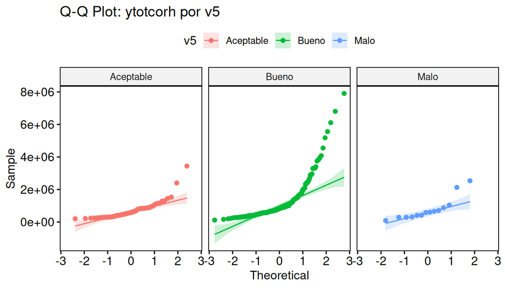

```r
# 5. Visualización Q-Q (Diagnóstico de normalidad)
ggqqplot(
  data = muestra_exploratoria,
  x = var_num,
  facet.by = var_grupo,
  color = var_grupo,
  title = paste("Q-Q Plot:", var_num, "por", var_grupo)
)
```

Se observan desviaciones importantes en el comportamiento de los datos, lo que sugiere el incumplimiento de la condición de normalidad.

## Formulación de hipótesis

Para evaluar la existencia de diferencias en el ingreso promedio según el estado de conservación del piso, se plantean las siguientes hipótesis:

$H_0$ = No existen diferencias en el ingreso total promedio de los hogares según el estado de conservación de su piso.

**Hipótesis Nula ($H_0$):**
$$H_0: \mu_{Bueno} = \mu_{Aceptable} =
\mu_{Malo}$$

$H_A$ = Existen diferencias en el ingreso total promedio de al menos uno de los grupos de conservación de piso respecto a los demás.

**Hipótesis Alternativa ($H_A$):**
$$H_A: \exists \, i, j \in \{1, 2, 3\} \text{ tal
que } \mu_i \neq \mu_j$$

Donde $\mu_1, \mu_2, \mu_3$ representan el ingreso total promedio de los hogares clasificados en los estados de conservación “Bueno”, “Aceptable” y “Malo”, respectivamente.

## Estadístico de interés

De acuerdo a la pregunta e hipótesis planteada, el estadístico a analizar será la media. Se puede justificar su uso, debido a la naturaleza de la variable bajo estudio “ingreso total promedio de los hogares”. Es una variable cuantitativa que presenta una escala de razón, ya que presenta un cero absoluto y la diferencia de pasar a ganar 400.000 a 600.000, es la misma que pasar de 600.000 a 800.000 pesos chilenos.

## Remuestreo

```r
# Variables
alfa <- 0.5
gamma <- 0.2
R <- 2000

# Análisis robusto con bootstrapping
formula_est <- as.formula(paste(var_num, "~", var_grupo))

# Prueba ómnibus
resultado_omnibus <- t1waybt(formula_est, data = muestra_exploratoria, tr = gamma, nboot = R)
print(resultado_omnibus)
```

```
## Call:
## t1waybt(formula = formula_est, data = muestra_exploratoria, tr = gamma,
##     nboot = R)
##
## Effective number of bootstrap samples was 2000.
##
## Test statistic: 7.2823
## p-value: 0.004
## Variance explained: 0.195
## Effect size: 0.442
```

```r
# Análisis Post-hoc
if (resultado_omnibus$p.value < alfa) {
  resultado_posthoc <- mcppb20(formula_est, data = muestra_exploratoria, tr = gamma, nboot = R)
  print(resultado_posthoc)
}
```

```
## Call:
## mcppb20(formula = formula_est, data = muestra_exploratoria, tr = gamma,
##     nboot = R)
##
##                         psihat  ci.lower ci.upper p-value
## Aceptable vs. Bueno -273032.48 -459085.9 -99845.9   0.000
## Aceptable vs. Malo    26078.49 -626378.9 262482.8   0.965
## Bueno vs. Malo       299110.97 -338755.7 539517.1   0.221
```

## Conclusión

Luego, el procedimiento post-hoc + bootstrapping permite afirmar con 95% de confianza (sin considerar el 20% en extremos) que las personas que reportan un estado de conservación del piso “Bueno” presentan ingresos superiores a quienes indican un estado de conservación “Aceptable”. Para los demás pares, no es posible hallar diferencias significativas a partir de la muestra.

# Referencias

Jara, J. L., & Köhler, J. (s. f.). Inferencia y modelos estadísticos [Perusall].